# Análisis de Clusterización

Ricardo Macías Bohórquez

21 de October de 2024

# Análisis de Clusterización

En este documento, aprenderemos a realizar **análisis de clustering (agrupamiento)** para identificar grupos o patrones ocultos en los datos. Exploraremos los siguientes métodos: - **K-means**: Un algoritmo de clustering basado en particiones. - **Clustering Jerárquico**: Un método que organiza los datos en una jerarquía de clusters. - **DBSCAN**: Un método basado en densidad que identifica clusters en regiones densamente pobladas.

## 1. Conceptos Fundamentales

### 1.1 ¿Qué es el Clustering?

El **clustering** es una técnica de análisis multivariado que tiene como objetivo dividir un conjunto de datos en grupos (clusters) basados en la similitud de sus observaciones. Las observaciones dentro de un grupo son similares entre sí y diferentes de las observaciones en otros grupos.

Existen varios métodos de clustering, cada uno con diferentes enfoques para encontrar patrones en los datos.

## 2. K-means Clustering

### 2.1 Explicación

El **K-means** es uno de los métodos de clustering más comunes. Su objetivo es particionar un conjunto de datos en **K** clusters, minimizando la distancia dentro de cada cluster y maximizando la distancia entre clusters.

#### **Objetivo**:

- Minimizar la suma de las distancias cuadradas entre las observaciones y el centroide de cada cluster.

#### **Pasos del algoritmo**:

1. Inicializar aleatoriamente **K** centroides.
2. Asignar cada observación al cluster más cercano (según la distancia euclidiana).
3. Recalcular los centroides como la media de las observaciones de cada cluster.
4. Repetir los pasos 2 y 3 hasta que no haya cambios significativos en los centroides.

### 2.2 Ejemplo: K-means en `iris`

#### 1. Cargar los datos y seleccionar las variables

```r
# Cargar la base de datos iris
data(iris)

# Seleccionar las variables numéricas
iris_numerico <- iris[, 1:4]

# Escalar los datos
iris_escalado <- scale(iris_numerico)

# Ver las primeras filas de los datos escalados
head(iris_escalado)
```

```
##      Sepal.Length Sepal.Width Petal.Length Petal.Width
## [1,]   -0.8976739  1.01560199    -1.335752   -1.311052
## [2,]   -1.1392005 -0.13153881    -1.335752   -1.311052
## [3,]   -1.3807271  0.32731751    -1.392399   -1.311052
## [4,]   -1.5014904  0.09788935    -1.279104   -1.311052
## [5,]   -1.0184372  1.24503015    -1.335752   -1.311052
## [6,]   -0.5353840  1.93331463    -1.165809   -1.048667
```

#### 2. Determinar el número óptimo de clusters (Elbow method)

Para determinar el número óptimo de clusters, utilizamos el **método del codo (Elbow Method)**, que evalúa la suma de las distancias cuadradas dentro de los clusters (inertia) para diferentes valores de **K**.

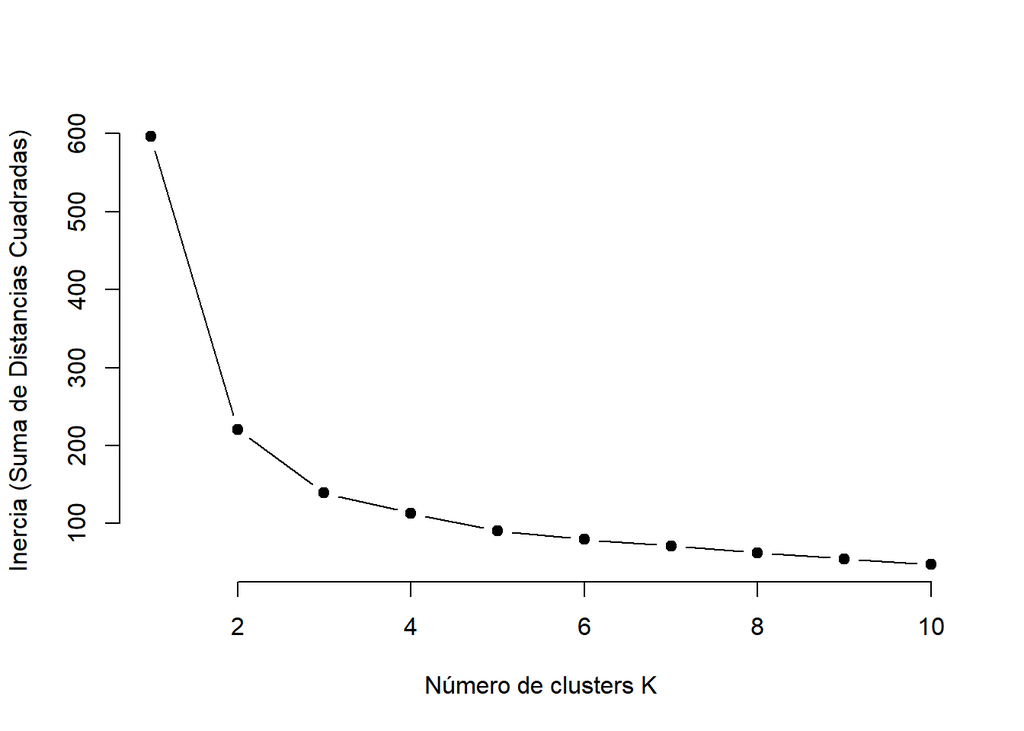

```r
# Calcular el codo para determinar el número óptimo de clusters
set.seed(123)
inercia <- sapply(1:10, function(k) {kmeans(iris_escalado, centers = k, nstart = 20)$tot.withinss})

# Graficar el codo
plot(1:10, inercia, type = "b", pch = 19, frame = FALSE,
     xlab = "Número de clusters K", ylab = "Inercia (Suma de Distancias Cuadradas)")
```

#### 3. Realizar el clustering K-means

```r
# Ajustar el modelo K-means con K = 3 (según el codo)
set.seed(123)
modelo_kmeans <- kmeans(iris_escalado, centers = 3, nstart = 20)

# Ver los resultados del clustering
modelo_kmeans$cluster
```

```
##   [1] 1 1 1 1 1 1 1 1 1 1 1 1 1 1 1 1 1 1 1 1 1 1 1 1 1 1 1 1 1 1 1 1 1 1 1 1 1
##  [38] 1 1 1 1 1 1 1 1 1 1 1 1 1 3 3 3 2 2 2 3 2 2 2 2 2 2 2 2 3 2 2 2 2 3 2 2 2
##  [75] 2 3 3 3 2 2 2 2 2 2 2 3 3 2 2 2 2 2 2 2 2 2 2 2 2 2 3 2 3 3 3 3 2 3 3 3 3
## [112] 3 3 2 2 3 3 3 3 2 3 2 3 2 3 3 2 3 3 3 3 3 3 2 2 3 3 3 2 3 3 3 2 3 3 3 2 3
## [149] 3 2
```

#### 4. Visualización de los clusters

```r
# Instalar y cargar el paquete factoextra si es necesario
# install.packages("factoextra")
library(factoextra)
```

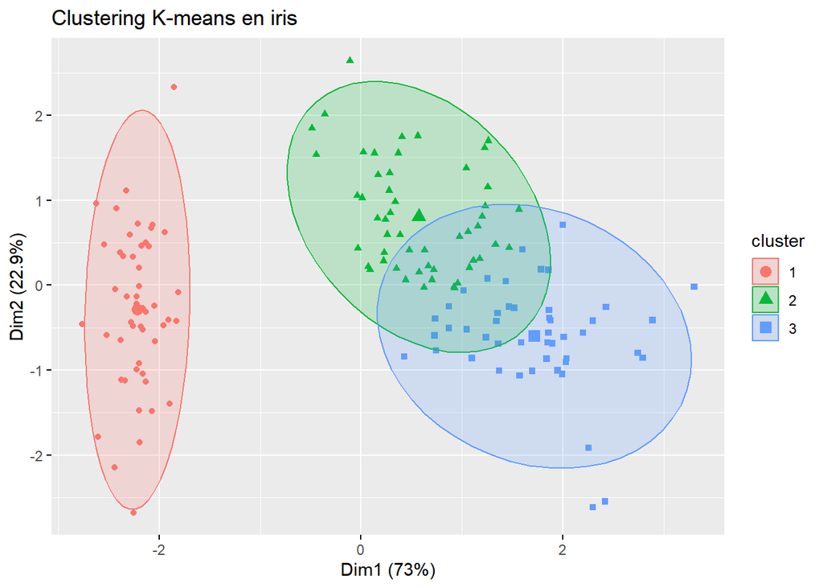

```r
# Visualizar los clusters
fviz_cluster(modelo_kmeans, data = iris_escalado, geom = "point", ellipse.type = "norm") +
  labs(title = "Clustering K-means en iris")
```

### 2.3 Interpretación

- **Centroides**: Representan el punto medio de cada cluster.
- **Distancias dentro de los clusters**: Una baja suma de distancias dentro de los clusters indica una buena cohesión.
- **Separación entre clusters**: Los clusters bien definidos estarán separados en el gráfico.

## 3. Clustering Jerárquico

### 3.1 Explicación

El **Clustering Jerárquico** es un método que agrupa las observaciones de manera secuencial, creando una jerarquía de clusters. Puede ser **aglomerativo** (se empiezan con cada observación en su propio cluster y se fusionan clusters) o **divisivo** (se comienza con un solo cluster que se divide recursivamente).

#### **Pasos del método aglomerativo**:

1. Calcular la matriz de distancias entre observaciones.
2. Combinar los clusters más cercanos.
3. Repetir hasta que todas las observaciones estén en un único cluster.

### 3.2 Ejemplo: Clustering Jerárquico en `iris`

#### 1. Calcular la matriz de distancias y realizar el clustering jerárquico

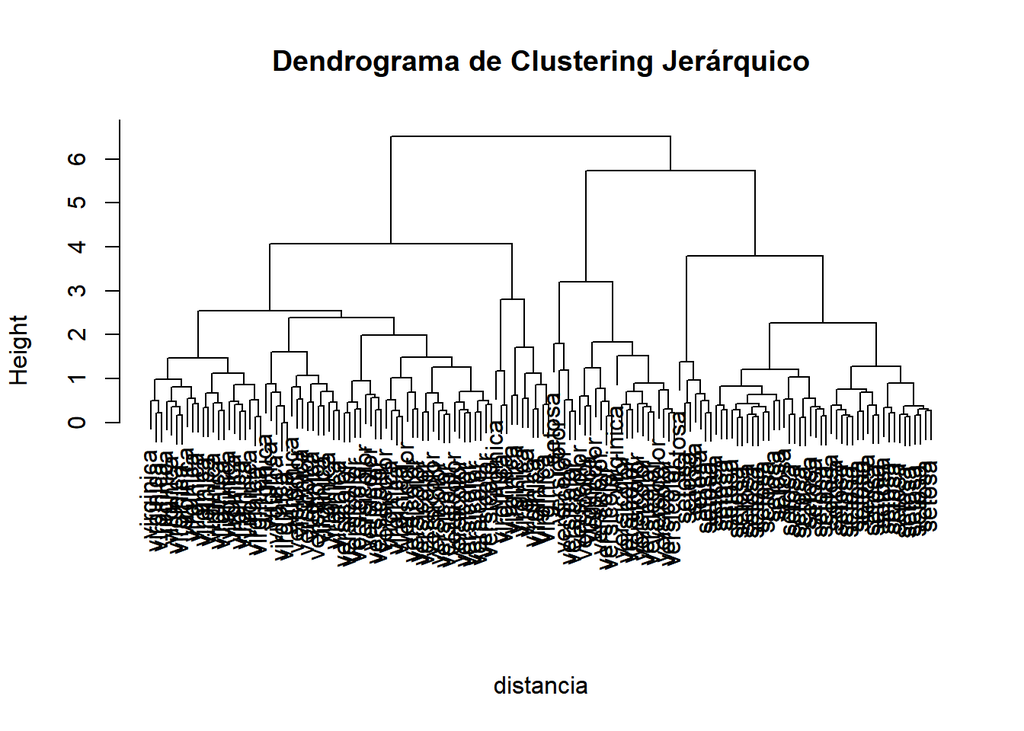

```r
# Calcular la matriz de distancias euclidianas
distancia <- dist(iris_escalado, method = "euclidean")

# Realizar el clustering jerárquico usando el método de enlace completo
clust_jerarquico <- hclust(distancia, method = "complete")

# Graficar el dendrograma
plot(clust_jerarquico, labels = iris$Species, main = "Dendrograma de Clustering Jerárquico", sub = "")
```

#### 2. Cortar el dendrograma para obtener K clusters

```r
# Cortar el dendrograma en 3 clusters
grupos_jerarquico <- cutree(clust_jerarquico, k = 3)

# Visualizar los clusters
table(grupos_jerarquico, iris$Species)
```

```
##
## grupos_jerarquico setosa versicolor virginica
##                 1     49          0         0
##                 2      1         21         2
##                 3      0         29        48
```

### 3.3 Interpretación

- **Dendrograma**: Muestra cómo se combinan los clusters a diferentes niveles de similitud.
- **Corte en K clusters**: Al cortar el dendrograma en un punto, obtenemos K clusters.

## 4. DBSCAN: Clustering basado en densidad

### 4.1 Explicación

**DBSCAN (Density-Based Spatial Clustering of Applications with Noise)** es un método de clustering que agrupa puntos densamente conectados y separa aquellos que están en regiones de baja densidad (considerados como ruido).

#### **Parámetros clave**:

- **Epsilon (eps)**: Define la distancia máxima para considerar puntos como vecinos.
- **MinPts**: Número mínimo de puntos para considerar una región como densa.

### 4.2 Ejemplo: DBSCAN en `iris`

#### 1. Ajustar el modelo DBSCAN

```r
# Instalar y cargar el paquete dbscan si es necesario
# install.packages("dbscan")
library(dbscan)
# Ajustar el modelo DBSCAN
modelo_dbscan <- dbscan(iris_escalado, eps = 0.5, minPts = 5)

# Ver los clusters
modelo_dbscan$cluster
```

```
##   [1] 1 1 1 1 1 1 1 1 1 1 1 1 1 1 0 0 1 1 1 1 1 1 1 1 1 1 1 1 1 1 1 1 0 0 1 1 1
##  [38] 1 1 1 1 0 1 1 1 1 1 1 1 1 2 2 2 2 2 2 0 0 2 0 0 2 0 2 2 2 2 2 0 2 2 2 0 2
##  [75] 2 2 2 2 2 2 2 2 2 2 2 0 2 0 2 2 2 2 2 0 2 2 2 2 0 2 0 2 2 2 2 0 0 0 0 0 2
## [112] 2 2 2 0 2 2 0 0 0 2 2 0 2 2 0 2 2 2 0 0 0 2 2 2 0 0 2 2 2 2 2 2 2 2 2 2 2
## [149] 0 2
```

#### 2. Visualización de los clusters

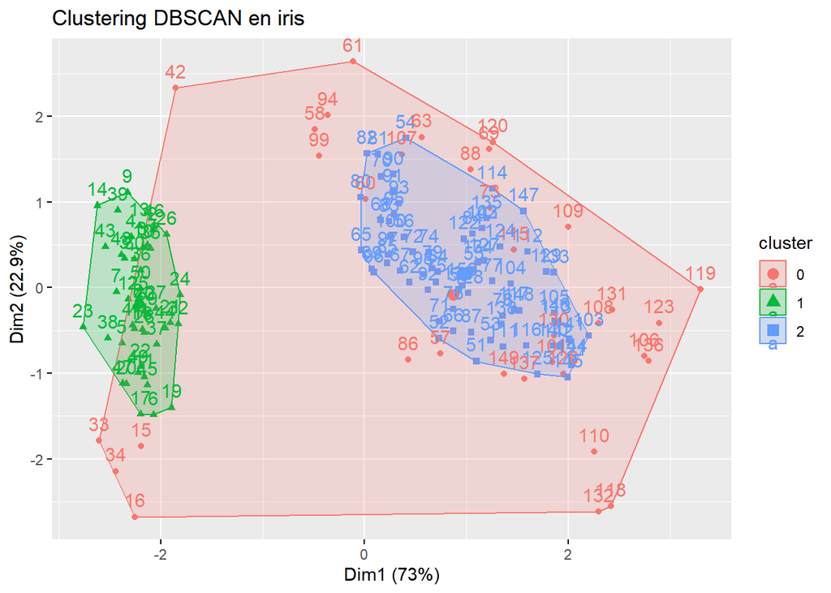

```r
# Visualizar los clusters de DBSCAN
fviz_cluster(list(data = iris_escalado, cluster = modelo_dbscan$cluster)) +
  labs(title = "Clustering DBSCAN en iris")
```

### 4.3 Interpretación

- **Clusters densos**: Los puntos en regiones densas se agrupan en clusters.
- **Ruido**: Los puntos en regiones de baja densidad se etiquetan como ruido (cluster 0).

## 5. Ejercicios Prácticos

### **Ejercicio 1**: K-means en otro conjunto de datos

Realiza el clustering K-means en el conjunto de datos `mtcars`. Determina el número óptimo de clusters utilizando el método del codo y visualiza los resultados.

```r
# Tu código aquí
```

**Mostrar solución**

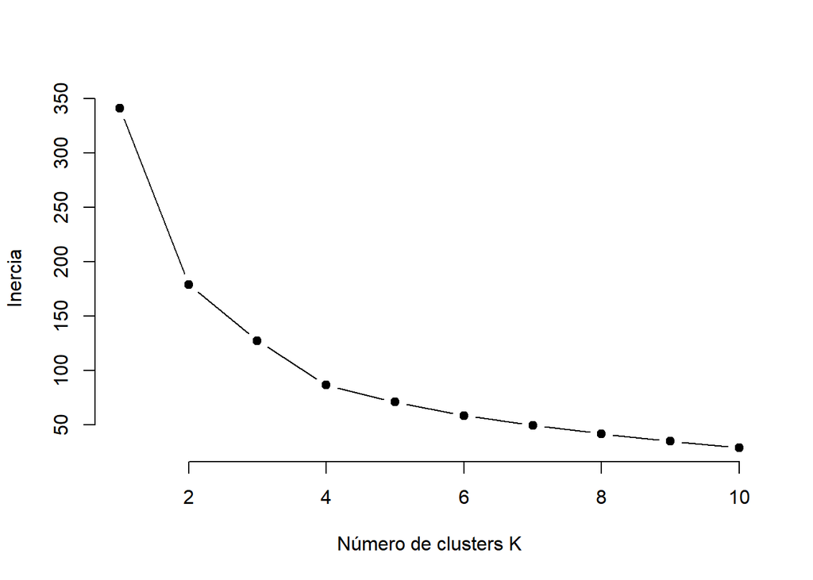

```r
# Escalar los datos de mtcars
mtcars_escalado <- scale(mtcars)

# Calcular el codo
set.seed(123)
inercia_mtcars <- sapply(1:10, function(k) {kmeans(mtcars_escalado, centers = k, nstart = 20)$tot.withinss})

# Graficar el codo
plot(1:10, inercia_mtcars, type = "b", pch = 19, frame = FALSE,
     xlab = "Número de clusters K", ylab = "Inercia")
```

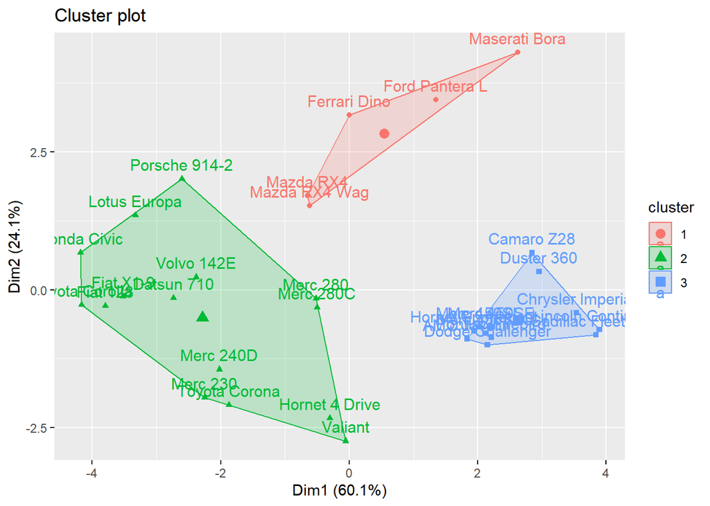

```r
# Ajustar el modelo K-means
modelo_kmeans_mtcars <- kmeans(mtcars_escalado, centers = 3, nstart = 20)

# Visualizar los clusters
fviz_cluster(modelo_kmeans_mtcars, data = mtcars_escalado)
```

### **Ejercicio 2**: Clustering Jerárquico en otro conjunto de datos

Realiza el clustering jerárquico en el conjunto de datos `mtcars`. Visualiza el dendrograma y corta el árbol para obtener 4 clusters.

```r
# Tu código aquí
```

**Mostrar solución**

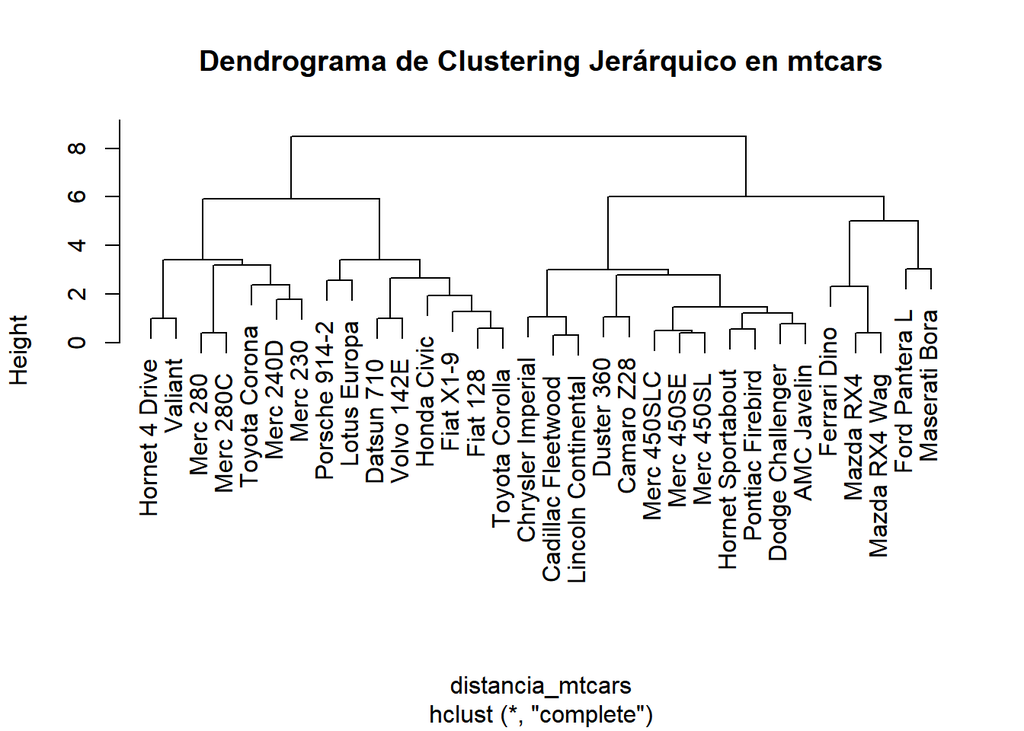

```r
# Calcular la matriz de distancias
distancia_mtcars <- dist(mtcars_escalado, method = "euclidean")

# Realizar el clustering jerárquico
clust_jerarquico_mtcars <- hclust(distancia_mtcars, method = "complete")

# Graficar el dendrograma
plot(clust_jerarquico_mtcars, main = "Dendrograma de Clustering Jerárquico en mtcars")
```

```r
# Cortar el dendrograma en 4 clusters
grupos_jerarquico_mtcars <- cutree(clust_jerarquico_mtcars, k = 4)

# Ver los clusters
table(grupos_jerarquico_mtcars)
```

```
## grupos_jerarquico_mtcars
##  1  2  3  4
##  5  8  7 12
```

### **Ejercicio 3**: DBSCAN en otro conjunto de datos

Ajusta un modelo DBSCAN en `mtcars`, ajusta los parámetros `eps` y `minPts`, y visualiza los clusters.

```r
# Tu código aquí
```

**Mostrar solución**

```r
# Ajustar el modelo DBSCAN
modelo_dbscan_mtcars <- dbscan(mtcars_escalado, eps = 1, minPts =3)

# Ver los clusters
modelo_dbscan_mtcars$cluster
```

```
##  [1] 0 0 0 0 1 0 0 0 0 0 0 1 1 1 2 2 2 3 0 3 0 1 1 0 1 3 0 0 0 0 0 0
```

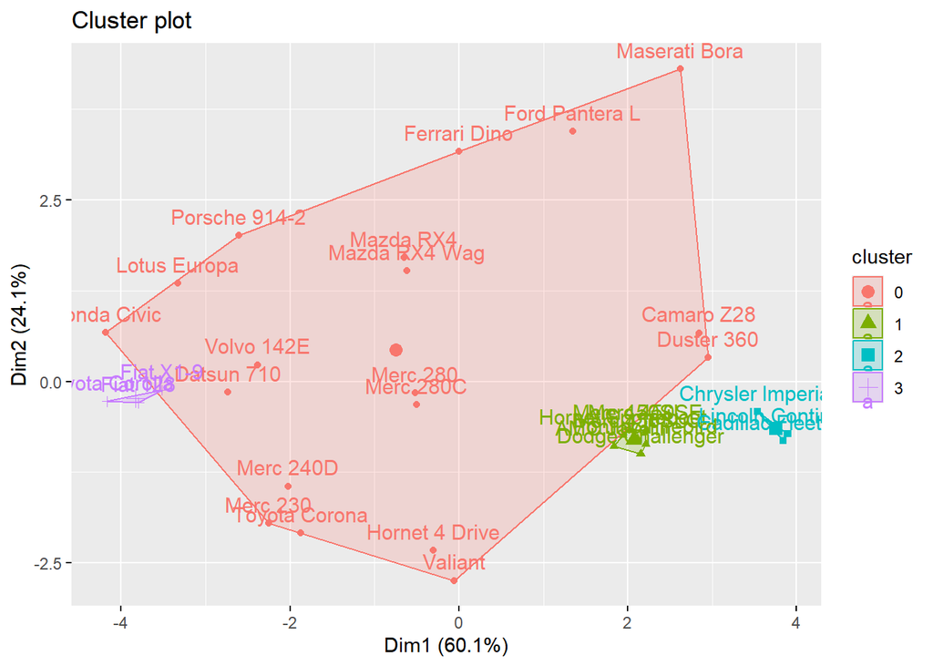

```r
# Visualizar los clusters
fviz_cluster(list(data = mtcars_escalado, cluster = modelo_dbscan_mtcars$cluster))
```